# Data diff

25 March, 2022

# 1 Introduction

In the framework of `daap`, `git` enables joint versioning of data and code. Additionally `git` provides deep coverage for change tracking code. However, when it comes to data, our ability to track change as at only at a very high/metadata level. While, `git` can track changes in text, text change tracking is not suitable for tracking data changes. This leaves a gap in our ability to `diff`.

# 2 Related work

Various packages have come along with utilities that could help characterize or compare tabular data. Examples include, [`compareDF`](https://github.com/alexsanjoseph/compareDF), [`waldo`](https://waldo.r-lib.org/index.html), [`arsenal`](https://cran.r-project.org/web/packages/arsenal/vignettes/comparedf.html), [`janitor`](http://sfirke.github.io/janitor/), and [`pointblank`](https://rich-iannone.github.io/pointblank/index.html).  
Comparisons provided by these packages, while get us closer to something akin to a utility that could help us interpret changes as `diff` does, they typically fall short. For example, `compareDF`, as the package that most directly seeks to mimic a `git` type `diff` functionality, rather than aiming for what’s the spirit of diff (i.e. enabling the developer to interpret differences) mimics text tracking functionality of `diff`, which as mentioned is not suitable for data. As a concrete example, from information perspective, reordering of columns and rows does not change the information-content of a data table. However, both `git` and `compareDF` treat row re-arrangement as change by default (i.e. when you don’t specify a grouping variable). Furthermore, all mentioned packages shy away from statistical information tracking. Authors, may have thought about and consciously decided to exclude that from the scope of their projects, given complexities of general purpose tools for what could be akin to anomaly detection. However, given the value of such approaches, even limited application of statistical approaches (e.g. finding univariate extreme values which is fairly robust), could move us closer to having tools that provide actionable `diff` like functionality for data.

# 3 Method:

The illustration below shows a possible step-wise flow to implementing a diff functionality.

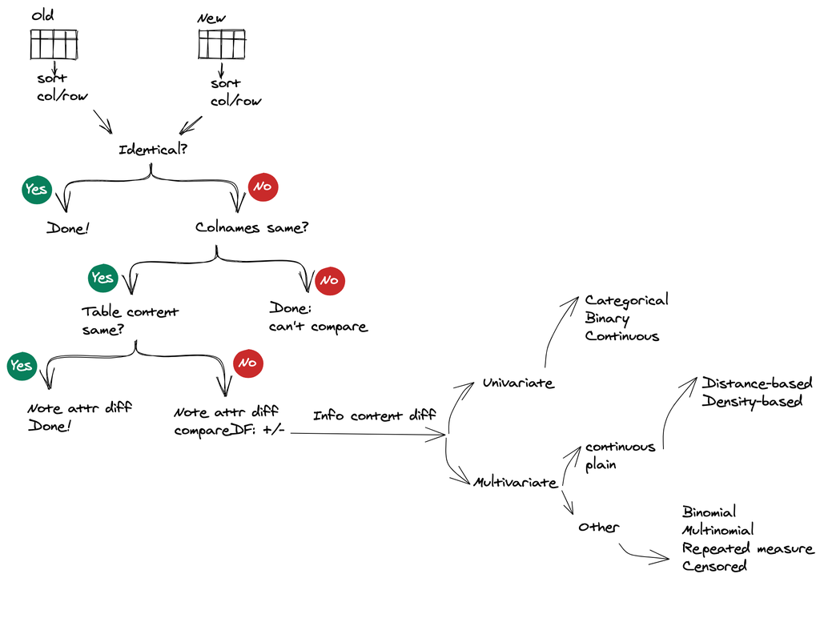

Output of a `diff` call generated by this or similar workflow, combines data validation type comparison as well as information content type comparison to provide more informative,interpretable and ultimately actionable summary of the differences.

# 4 Results (preliminary)

The are two components in the outlined workflow:

1. Form or base content diff
2. Information content diff

Form or base content diff is mechanical and quite straight forward to implement. In contrast, information content `diff` ventures in the realm of unsupervised learning and hence more complex.

## 4.1 Form and base content `diff`

Here, I implemented the data validation type `diff` and added a minimalist venture into the info content `diff` using a simple PCA approach for demonstration purposes.

First we simulate some mock data. This is to help us test a few different simple conditions:

1. When data tables being compared are identical
2. When order of columns and rows are changed
3. When attributes are the same but content change
4. When attributes change but colnames are the same
5. When attributes change and colnames are different too
6. When new records are added to a table

```r
d <- d_test()
data.tree::FromListSimple(d)
```

```
##               levelName
## 1  Root
## 2   ¦--order
## 3   ¦   ¦--old
## 4   ¦   °--new
## 5   ¦--attrs
## 6   ¦   ¦--same
## 7   ¦   ¦   ¦--old
## 8   ¦   ¦   °--new
## 9   ¦   °--different
## 10  ¦       ¦--col_same
## 11  ¦       ¦   ¦--old
## 12  ¦       ¦   °--new
## 13  ¦       °--col_diff
## 14  ¦           ¦--old
## 15  ¦           °--new
## 16  ¦--identical
## 17  ¦   ¦--old
## 18  ¦   °--new
## 19  °--records_added
## 20      ¦--old
## 21      °--new
```

### 4.1.1 Identical

```r
ddiff_rpt <- ddiff(d_new = d$identical$new, d_old = d$identical$old)
ddiff_rpt[-7] %>%
  as.data.frame() %>%
  dplyr::glimpse()
```

```
## Rows: 1
## Columns: 6
## $ comparable      <lgl> TRUE
## $ d_match         <lgl> TRUE
## $ attrnames_match <lgl> TRUE
## $ equivalent      <lgl> TRUE
## $ identical       <lgl> TRUE
## $ message         <chr> "Data tables are identical"
```

**message:** Data tables are identical

### 4.1.2 Change in order

Here, simply the rows and column orders are randomly changed. The resultant tables while not identical are equivalent from data perspective.

```r
d$order$old %>%
  head() %>%
  knitr::kable(.)
```

| nm_1 | nm_2 | nm_3 | cat_1 | bin_1 | id |
| --- | --- | --- | --- | --- | --- |
| -1.1894537 | 1.4234235 | 0.1872768 | c | Y | id_1 |
| 0.3885812 | -1.0426581 | 1.9137194 | b | Y | id_2 |
| -0.3443333 | 0.0011692 | -0.6226594 | c | Y | id_3 |
| -0.5478961 | 1.0904552 | -1.0641839 | c | N | id_4 |
| 0.9806622 | -0.9987152 | -0.3422707 | b | N | id_5 |
| -0.2366460 | 0.5348300 | -0.1013222 | b | N | id_6 |

```r
d$order$new %>%
  head() %>%
  knitr::kable(.)
```

|  | nm_2 | cat_1 | bin_1 | id | nm_3 | nm_1 |
| --- | --- | --- | --- | --- | --- | --- |
| 20 | -0.9688690 | c | Y | id_20 | 0.2379574 | -0.7002809 |
| 10 | 0.2551949 | a | N | id_10 | 0.1783597 | -0.1830838 |
| 16 | -1.8266932 | b | N | id_16 | -0.2162799 | -0.2605846 |
| 11 | 1.5047414 | c | Y | id_11 | 1.7036697 | 0.5186300 |
| 19 | -0.5903992 | c | N | id_19 | -1.1511721 | 0.5042705 |
| 18 | -2.3685212 | a | N | id_18 | 0.7847898 | 1.4065584 |

```r
ddiff_rpt <- ddiff(d_new = d$order$new, d_old = d$order$old)
ddiff_rpt[-7] %>%
  as.data.frame() %>%
  dplyr::glimpse()
```

```
## Rows: 1
## Columns: 6
## $ comparable      <lgl> TRUE
## $ d_match         <lgl> TRUE
## $ attrnames_match <lgl> TRUE
## $ equivalent      <lgl> TRUE
## $ identical       <lgl> FALSE
## $ message         <chr> "Data table contents and attr names match: differences…
```

**message:** Data table contents and attr names match: differences are limited to row or col orders or other attribute values

### 4.1.3 Attributes the same but content change

Here, all table attributes are the same, just row content is changed.

```r
ddiff_rpt <- ddiff(d_new = d$attrs$same$new, d_old = d$attrs$same$old)
ddiff_rpt[-7] %>%
  as.data.frame() %>%
  dplyr::glimpse()
```

```
## Rows: 1
## Columns: 6
## $ comparable      <lgl> TRUE
## $ d_match         <lgl> FALSE
## $ attrnames_match <lgl> TRUE
## $ equivalent      <lgl> FALSE
## $ identical       <lgl> FALSE
## $ message         <chr> "See comp_obj for detail comparison\n"
```

```r
compareDF::create_output_table(ddiff_rpt$comp_obj)
```

| rowname | chng_type | nm_1 | nm_2 | nm_3 | cat_1 | bin_1 | id |
| --- | --- | --- | --- | --- | --- | --- | --- |
| 1 | + | 2.458 | 1.236 | 0.141 | b | N | id_01 |
| 1 | - | -1.189 | 1.423 | 0.187 | c | Y | id_1 |

**message:** See comp_obj for detail comparison

### 4.1.4 Attributes different colnames same

Here, there is a single attribute added, but otherwise the contents are the same.

```r
ddiff_rpt <- ddiff(d_new = d$attrs$different$col_same$new, d_old = d$attrs$different$col_same$old)
ddiff_rpt[-7] %>%
  as.data.frame() %>%
  dplyr::glimpse()
```

```
## Rows: 1
## Columns: 6
## $ comparable      <lgl> TRUE
## $ d_match         <lgl> TRUE
## $ attrnames_match <lgl> FALSE
## $ equivalent      <lgl> FALSE
## $ identical       <lgl> FALSE
## $ message         <chr> "Data table contents match but attr names may differ\n…
```

**message:** Data table contents match but attr names may differ Attributes added key_1

### 4.1.5 Attributes different colnames different

Here, a new column is added. As comparability assumes we are comparing the same set of features, it alerts the developer to the issue, leaving it to her take the right course of action.

```r
ddiff_rpt <- ddiff(d_new = d$attrs$different$col_diff$new, d_old = d$attrs$different$col_diff$old)
ddiff_rpt[-7] %>%
  as.data.frame() %>%
  dplyr::glimpse()
```

```
## Rows: 1
## Columns: 6
## $ comparable      <lgl> FALSE
## $ d_match         <lgl> FALSE
## $ attrnames_match <lgl> FALSE
## $ equivalent      <lgl> FALSE
## $ identical       <lgl> FALSE
## $ message         <chr> "Colnames are different. Ensure d_new and d_old being …
```

**message:** Colnames are different. Ensure d_new and d_old being compared have the same colnames

### 4.1.6 New records added

Here 20 new records are added. All other aspects of the data table attributes are the same. `compareDF` does provide `git` like comparison, showing added records. However, you can imagine with larger number of rows and columns added, the value of visual display of +/- is minimal. Additionally, trends can’t be spotted. Can you see a difference between rows 21-30 vs. 31-40?

```r
ddiff_rpt <- ddiff(d_new = d$records_added$new, d_old = d$records_added$old)
ddiff_rpt[-7] %>%
  as.data.frame() %>%
  dplyr::glimpse()
```

```
## Rows: 1
## Columns: 6
## $ comparable      <lgl> TRUE
## $ d_match         <lgl> FALSE
## $ attrnames_match <lgl> TRUE
## $ equivalent      <lgl> FALSE
## $ identical       <lgl> FALSE
## $ message         <chr> "See comp_obj for detail comparison\n"
```

```r
compareDF::create_output_table(ddiff_rpt$comp_obj)
```

| rowname | chng_type | nm_1 | nm_2 | nm_3 | cat_1 | bin_1 | id |
| --- | --- | --- | --- | --- | --- | --- | --- |
| 21 | + | 0.615 | -0.858 | -0.156 | a | Y | id_21 |
| 22 | + | -0.6 | 0.908 | -0.877 | c | Y | id_22 |
| 23 | + | -1.369 | 1.423 | -0.34 | a | Y | id_23 |
| 24 | + | -0.195 | -1.487 | -0.711 | b | Y | id_24 |
| 25 | + | 1.459 | -0.191 | 0.799 | b | Y | id_25 |
| 26 | + | -0.983 | -0.939 | -2.284 | c | N | id_26 |
| 27 | + | -0.779 | 0.86 | -0.1 | c | N | id_27 |
| 28 | + | 1.776 | -1.516 | 0.711 | b | N | id_28 |
| 29 | + | -1.266 | 0.788 | 0.014 | a | N | id_29 |
| 30 | + | 1.302 | 0.071 | -0.721 | c | N | id_30 |
| 31 | + | 5.342 | 3.155 | 4.448 | b | Y | id_31 |
| 32 | + | 5.672 | 5.122 | 6.219 | a | Y | id_32 |
| 33 | + | 5.671 | 5.951 | 5.21 | b | N | id_33 |
| 34 | + | 2.906 | 5.784 | 4.47 | a | Y | id_34 |
| 35 | + | 6.542 | 6.426 | 4.623 | b | Y | id_35 |
| 36 | + | 4.881 | 4.425 | 6.066 | a | Y | id_36 |
| 37 | + | 3.891 | 2.062 | 4.676 | b | Y | id_37 |
| 38 | + | 4.703 | 5.766 | 6.112 | a | N | id_38 |
| 39 | + | 3.049 | 4.464 | 4.925 | b | N | id_39 |
| 40 | + | 4.229 | 6.971 | 3.687 | b | N | id_40 |

**message:** See comp_obj for detail comparison

## 4.2 Information content `diff`

### 4.2.1 Example of info content type `diff`

Here we look at the same 20 records added using simple PCA analysis.

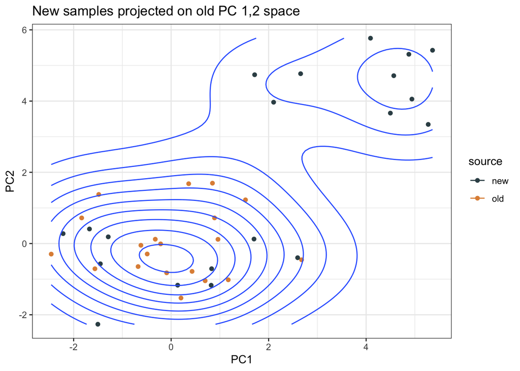

```r
prcomp(x = d$records_added$old[, c("nm_1", "nm_2", "nm_3")], retx = T,
       center = T, scale. = T) -> pc_old

newrecords_sc <- scale(d$records_added$new[-(1:20), c("nm_1", "nm_2", "nm_3")],
                       center = pc_old$center, scale = pc_old$scale)

new_records_hat <- newrecords_sc %*% pc_old$rotation
all_d <- rbind(
  data.frame(source = "old", pc_old$x),
  data.frame(source = "new", new_records_hat)
)

ggplot(all_d, aes(x = PC1, y = PC2)) +
  geom_point(aes(colour = source)) +
  ggsci::scale_color_jama() +
  geom_density_2d() +
  theme_bw() +
  ggtitle("New samples projected on old PC 1,2 space")
```

# 5 Further development

## 5.1 Univariate information content `diff`

Univariate approach can be considered the “lowest hanging fruit” in implementing information diff. On binary and categorical front, one could test conformity to the existing categories. On continuous variables, both rank-based and parametric approaches can easily be leveraged.

## 5.2 Multivariate information content `diff`

Multivariate approach to information content comparison has the most potential for enabling data developers to make actionable comparisons between data-sets that are being compared. However, the potential may not easily or fully be realized given the degree of complexity involved. Among the multivariate approaches, one may dichotomize the problem into those involving plain continuous data where the generative model can be reasonably approximated by a multivariate distribution (i.e. not censored or repeated measure such as time series) and everything else.

### 5.2.1 Multivariate `diff` for plain continuous data

Approaches such as matrix factorization, or distance-based anomaly detection could be leveraged. An example would be MSD (Modified Stahel-Donoho) estimator

### 5.2.2 Mutlivariate `diff` for anything but plain continuous data

Here `diff` is likely to require information to be supplied by the user to the algorithm for optimal results. For example, if time course structure is known, one may be able to make projections or interpolation and evaluate how likely or unlikely new data is compared with the old data.

# 6 References:

[1] Wada, Kazumi, and Hiroe Tsubaki. “Parallel computation of modified Stahel-Donoho estimators for multivariate outlier detection.” 2013 International Conference on Cloud Computing and Big Data. IEEE, 2013.